# Big Mountain Resort

John James john.james@nov8.ai

25 September, 2020

# Optimizing Value Creation, Maximizing Value Capture in the Ski Resort Industry

## Big Mountain Executive Summary

We’ve examined the facilities (over 35 features) and pricing for over 300 ski resorts across 34 states. Multiple models were developed and the results were cross-validated. The following summarizes the key insights from the analysis and modeling processes, **based upon the data provided**:

- Big Mountain Ski Resort’s current facilities, terrain and runs could support an adult weekend price of $94.22 - an increase of 16% over the current price, corresponding to an annual revenue increase north of $4.6M first-year on the current operations platform.
- Of the four scenarios under consideration, adding the additional run had the greatest revenue impact. This would support an addition $1.99 per adult weekend ticket, or an additional $700K in annual revenue.
- The facilities most important to customers are:
  - FastQuads
  - Runs
  - Snow Making
  - Vertical Drop

Disclaimer: The above insights were based upon the data provided. Further analysis of operating costs would be required to evaluate return on investment of the scenarios under consideration.

## Big Mountain Current Situation

Big Mountain’s is currently evaluating value creation and capture vis-a-vis its investment, pricing, and operations strategies. Their current adult weekend day price of $81 is a premium over the average price of resorts in their market segment, but that approach is problematic in several respects. First, it provides no insight into what constitutes value from the perspective of the customer. Second, it doesn’t reflect how and to what degree the resort delivers that value, and finally, the strategy doesn’t maximize value capture for the company. Consequently, investment and cost-cutting strategies cannot be considered on the basis of valuable market and customer data.

The analysis should help address questions such as:

1. How do we maximize price based upon the facilities currently in place?
2. What investment strategies would create the most value for the company in the short and long run?
3. How costs be cut without reducing value to the customer?

This market and customer data will yield better investment and cost-cutting decisions, optimize value creation for the customer, and maximize value capture for Big Mountain!

## Project Methods: Analysis and Modeling

To ensure that any conclusions would be supported by data and statistical rigor, extensive exploratory data analysis, feature engineering, and modeling efforts were conducted.

### Exploratory Data Analysis

Demographic and aggregate ski resort data by state was obtained to augment the ski resort data provided by Big Mountain.

#### State Ski Resort Data

The state ski resort data included the following for each of the 34 states within the scope of the analysis:

- resorts per state
- state total skiable area
- state total days open
- state total terrain parks
- state total night skiing
- state population
- state area in square miles.

The following summarizes Montana’s ranking for these features.

Table 1: Montana’s State Rank vis-a-vis Select State Resort Statistics

| measure | value | rank |
| --- | --- | --- |
| state_area | 147,040.0 | 3.0 |
| state_total_skiable_area | 214,10.0 | 4.0 |
| state_total_nightskiing | 710.0 | 8.0 |
| state_total_terrain_parks | 27.0 | 11.0 |
| resorts_per_state | 12.0 | 11.5 |
| state_total_days_open | 951.0 | 15.0 |
| state_population | 1,068,778.0 | 30.0 |

Based upon this initial observation, two additional features were created to describe the degree of competitiveness or *resort density* among the resorts and states.

- resorts per 100K capita
- resorts per 100K square miles.

Montana ranked 4th among the 34 states in terms of resorts per 100K people, but 24th in resorts per 100K square miles. This indicates that Montana may be one of the most competitive states for ski resort operators.

Next, the project considered the degree to which patterns in pricing at the state level were extant. The analysis revealed no discernible patterns in ticket price among the states; videlicet, knowing the state of a resort would reveal little about the adult weekend price for a resort. Consequently, all resorts would be included and state would not be a factor in the modeling process.

As such, four additional features for each resort were created:

- Ratio of resort skiable area to state total skiable area,
- Ratio of days open last year to state total days open,
- Ratio of terrain parks to state total terrain parks, and
- Ratio of night skiing to total state night skiing

#### Ski Resort Data

The ski resort data set was the focus of the second phase of the exploratory data analysis.

Table 2: Big Mountain Resort Rankings by Import Features

|  | AdultWeekend | vertical_drop | Snow Making_ac | total_chairs | fastQuads | Runs | LongestRun_mi | trams | SkiableTerrain_ac |
| --- | --- | --- | --- | --- | --- | --- | --- | --- | --- |
| Ranks | 51 | 28 | 6 | 17 | 14 | 20 | 11 | 212 | 5 |

To illuminate any relationships between the features and the adult weekend price, the team examined the distributions of each feature individually vis-a-vis ticket price. A correlation analysis revealed the following as highly correlated with ticket price:

Table 1Table 3: Features most highly correlated with adult weekend ticket price.

| Feature | Correlation |
| --- | --- |
| Snow Making_ac | 0.695764 |
| LongestRun_mi | 0.579602 |
| trams | 0.569015 |
| projectedDaysOpen | 0.529650 |
| SkiableTerrain_ac | 0.527750 |

Additionally, inter-feature correlations were examined illuminating non-trivial multicollinearity among the features. The most highly correlated features were:

Table 4: Inter-feature correlations

[output not shown]

A sizeable amount of multicollinearity was introduced by the state ratio features; hence, they contributed little to the analysis and were excused from service.

### Modeling

The objective at this stage was to create a model that would predict an *expected* adult weekend ticket price for Big Mountain, given current facilities, terrain and operating platform.

Two models were created:

1. Linear Regression Model
2. Random Forest Model

The linear regression model is based upon the assumption that there exists a linear relationship between the features and the target, adult weekend ticket price. The random forest model is based upon a series of prediction trees, or a forest, of predictions. The expected ticket price is the average of the predictions of the regression trees.

The modeling process was codified in a pipeline including the following steps:

- Impute missing values with their means
- Scale the features to have zero mean and unit variance
- The best of the 10 features were selected
- Train the models on those features
- Compute model performance

The following summarizes the cross-validated performance of the two algorithms:

Table 5: Performance of Linear Regression and Random Forests Models

| Metric | Linear Regression | Random Forests |
| --- | --- | --- |
| Coefficient of Determination (R2) | 0.632887 | 0.708161 |

The best model (Random Forests) was then used to predict the expected price based upon current facilities, terrain, and operating platform vis-a-vis those of over 300 other ski resorts across 34 states.

## Recommendations for Big Mountain

Based upon the data, analysis, and modeling above, the team recommends the following:

1. Big Mountain could sustain a 16% increase in adult weekend ticket price to $94.22. This would constitute a before tax revenue increase north of $4.6M first-year on the current operations platform.
2. Of the four scenarios being considered, the additional run and chair lift would support an additional ticket price increase of $1.99 per adult weekend ticket, resulting in an additional $700K in annual revenue first year.

Closing down up to 10 of the least used runs would have a non-trivial impact on price as indicated in Figure 1.

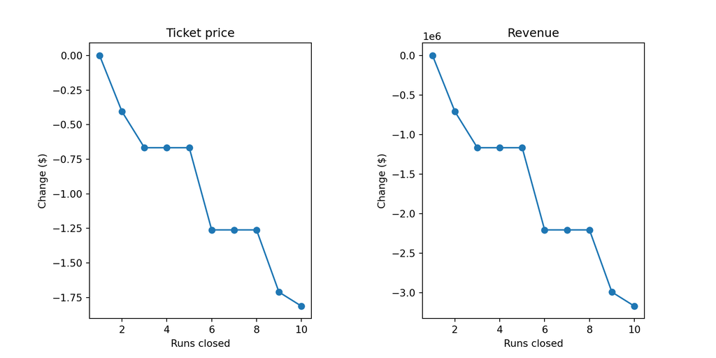

Figure 1: Big Mountain Resort Scenario #1 Price and Revenue Impact

## Next Steps

There are two efforts recommended as next steps.

1. Obtain operational cost data and incorporate that into the model to assess ROI.
2. Create an interactive dashboard that takes in real time operational, competitive, and macro-economic data and produces investment and pricing scenarios and long term return on investment.

The above reflects the work and conclusions of the entire team.

The appendix provides additional supporting data and visualizations.

## Appendix

### Ticket Price

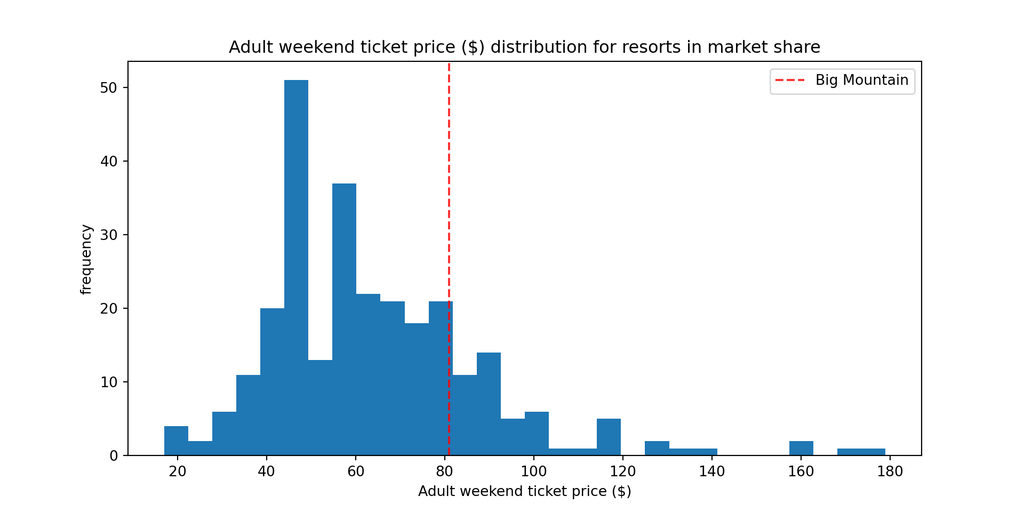

Figure 2: Big Mountain Resort Ranking by Adult Weekend Price

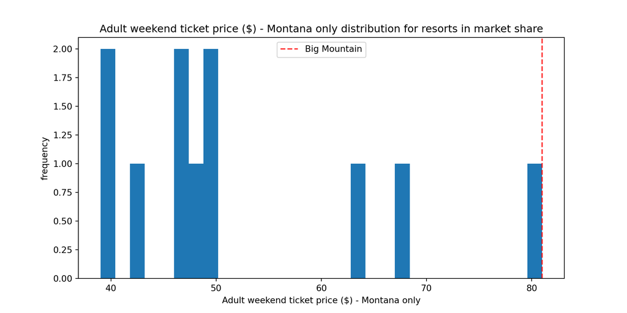

Figure 3: Big Mountain Resort Ranking by Adult Weekend Price within Montana

### Vertical Drop

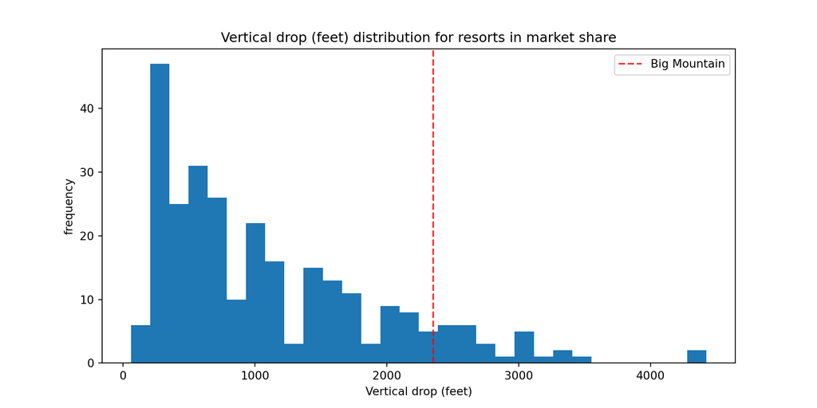

Figure 4: Big Mountain Resort Ranking by Vertical Drop

### Snow Making

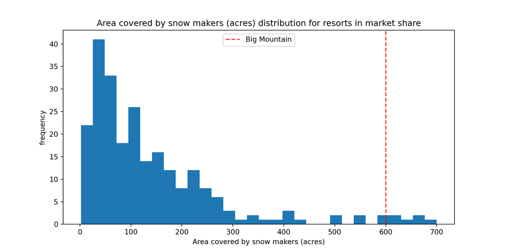

Figure 5: Big Mountain Resort Ranking by Snow Making

### Total Number of Chairs

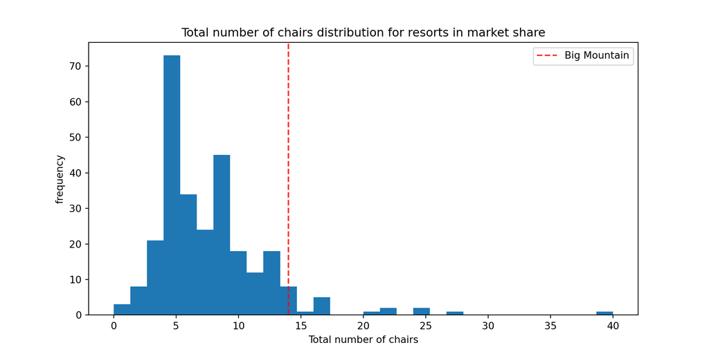

Figure 6: Big Mountain Resort Ranking by Total Number of Chairs

### Fast Quads

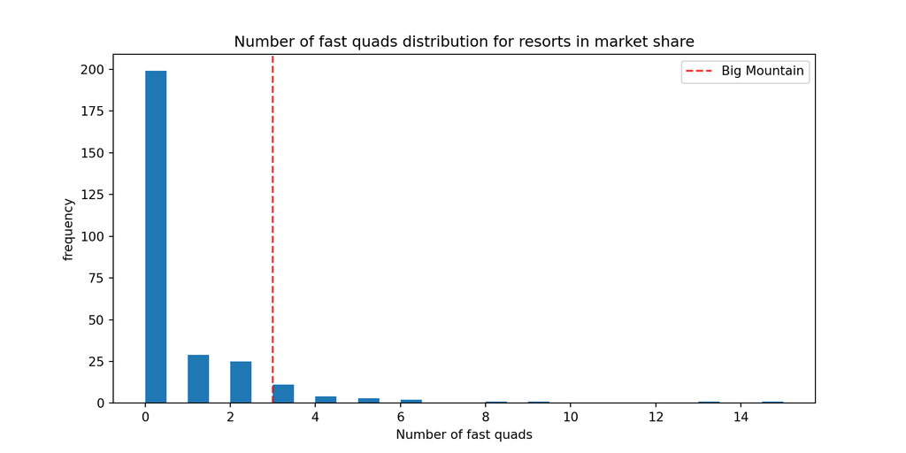

Figure 7: Big Mountain Resort Ranking by Fast Quads

### Runs

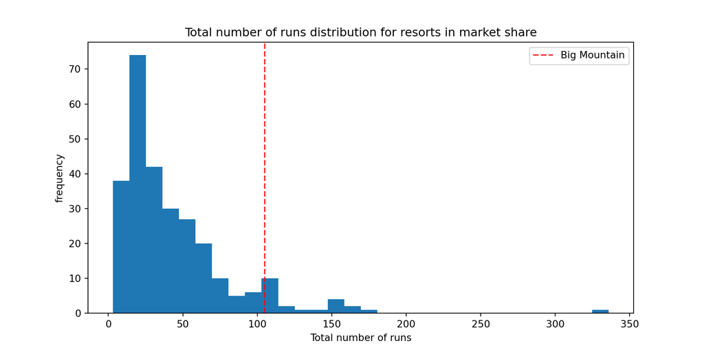

Figure 8: Big Mountain Resort Ranking by Runs

### Trams

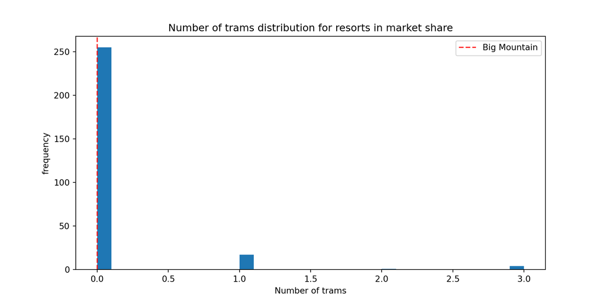

Figure 9: Big Mountain Resort Ranking by Trams

### Skiable Terrain Area

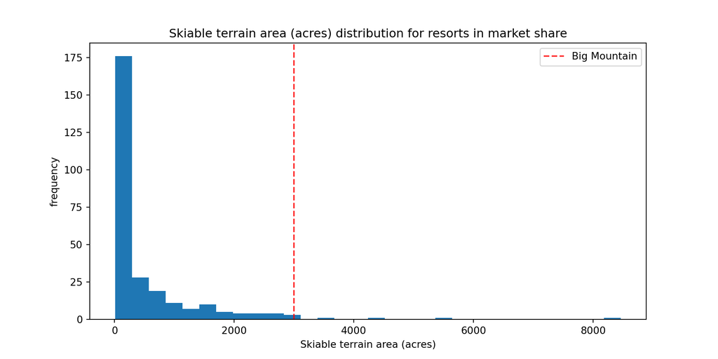

Figure 10: Big Mountain Resort Ranking Skiable Terrain Area